# Coursework Report

*N* removed NAs: 5

*N* removed <18: 29

**Correct typo age:** 14

*N* total clean: 134

| Group | *N* | *M*<sub>age</sub> | % green |
| --- | --- | --- | --- |
| Control | 69 | 20.97 | 53.62 |
| Experim | 65 | 20.83 | 37.95 |

| Gender | *N* | *M*<sub>age</sub> | % green |
| --- | --- | --- | --- |
| Female | 82 | 20.89 | 45.53 |
| Male | 33 | 20.73 | 47.47 |
| Other | 19 | 21.26 | 45.61 |

**Main analysis results**

**car:**  
χ<sup>2</sup>(1) = 6.06, *p* = .014

**cleaner:**  
χ<sup>2</sup>(1) = 2.44, *p* = .119

**dishwasher:**  
χ<sup>2</sup>(1) = 0.84, *p* = .358

[interactive chart not shown]

[figure not shown]

[interactive chart not shown]

# Coursework Report

Analysing Data, Spring 2020

# Methods

## Participants

*Table 1*. Summary of Participant Ages by Experimental Condition

[output not shown]

## Design

This experiment aimed to see whether high status increases preference for environmentally ‘green’ products over their more luxurious, non-green counterparts. This is a replication of Griskevicius et al (2010), to see if the same effect is found. The independent variable was whether participants took part in the status motives condition, and read a status motives story, or whether they were in the control condition, reading a control story. The study had a between-subjects design, meaning each participant only read one of the stories. Participants were told they would be tested on their memory of the stories, after an ‘interfering task’ (the product choices). The dependent variable was a factor, so participants chose between two options: a “green”, or luxury version of the same product, company, and price. The three products used were a car, a dishwasher, and a household cleaner. Due to this study being a replication, it was expected that participants who had status motives activated, were more likely to choose the green product over the luxury one than control participants. After data was collected, chi-squared tests were performed in order to see if this hypothesis was met.

# Results

A chi-squared analysis was performed for each product. A significant association was found between status condition and product preference for the car, *χ*<sup>2</sup>(1) = 6.06, *p* = 0.014. However, as figure 1 shows, participants with status motives activated tended to prefer the luxury product over the green one (66% vs 34%) and vice versa for the control group (57% chose green, 43% chose luxury). Therefore, as the test shows there is an association, status motives actually increased liking for the luxury car over the green one, contrasting the results found in Griskevicius et al (2010).

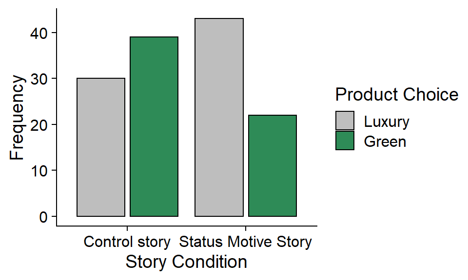

*Figure 1*. Frequency of Car Preference for Both Story conditions

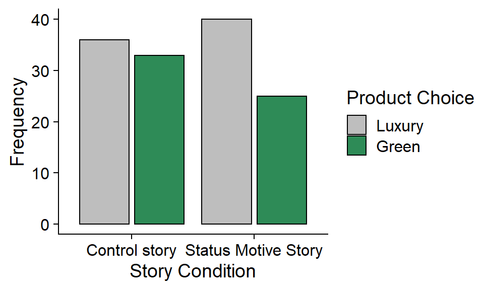

*Figure 2*. Frequency of Dishwasher Preference for Both Story Conditions

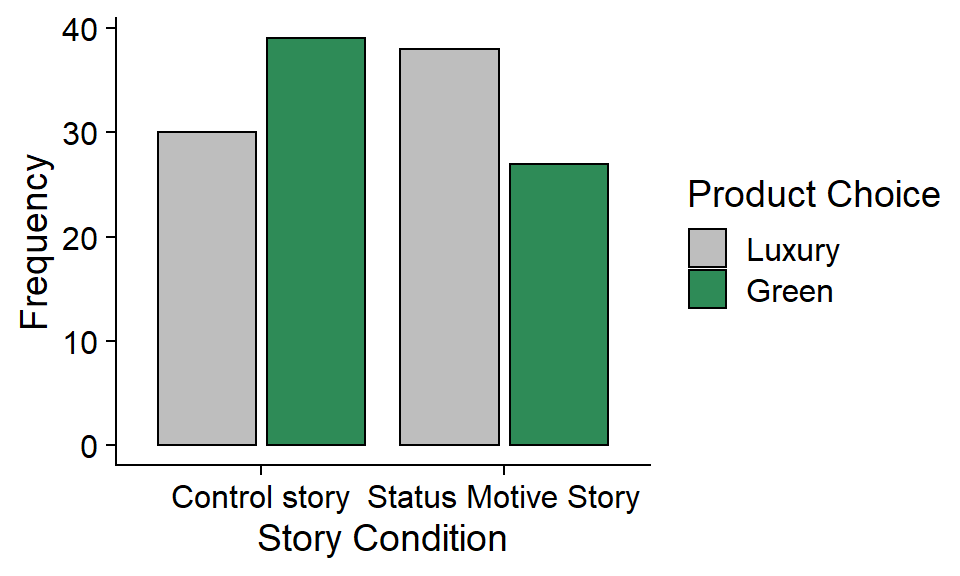

*Figure 3*. Frequency of Cleaner Preference for Both Story Conditions

Overall, the results do not show the same effect as that seen in the original study, suggesting status motives don’t effect liking for either luxury or green dishwashers or household cleaners, however they do appear to increase preference for luxury cars over environmentally-friendly cars.

# Discussion

### Summary

The question this study aimed to answer was whether high status leads to a preference for pro-environmental products over luxury, non-green products, as found in Griskevicius et al (2010). However, the results show that this effect was not found and instead suggest that status motives do not increase preference for either green or luxury products, except in the case of a car, which actually lead to preference for luxury. Therefore, overall this study did not replicate the findings of the original study and have given opposing evidence by suggesting high status can lead to the purchase of luxury items, even when a green version is available, implying that status can be gained through some luxury items such as cars more than the ‘green’ ones.

### Implications:

Griskevicius (2010) took the stance of the costly signalling theory, arguing people purchase environmentally-friendly products to display altruism, in turn increasing their status. Clearly, these results do not support this, as they have shown status does not affect purchasing choices either way usually, but can lead people to choosing luxury. Therefore, this study has conflicted the costly signalling theory, meaning the results found in the original study weren’t replicated.

Instead, this study supports traditional ideas highlighting the importance of self-indulgence over self-sacrifice, for high status individuals. The reason self indulgence may only be seen for the car could be because cars are seen by others more than dishwashers and cleaners and therefore, individuals may want to use these luxury cars to display their status. They may feel as though they deserve the nicer car, rather than feeling the need to benefit all of society by purchasing the green car. It could be possible that individuals’ gain goals (such as status) may outweigh normative goals (helping the environment) so they see themselves as gaining more by having a luxurious car, clearly displaying wealth and status (Steg et al, 2014). In terms of the other two products, there may be a balance between status and environmental goals, which explains why no significant difference was found between product choices.

This study suggests status may not be a fundamental desire, which has been previously argued by Leary, Jongman-Sereno, & Diebels (2014), however others have argued it is fundamental, for example Maslow’s (1943) hierarchy of needs placed status at the top as being one of the main goals for individuals in society. Anderson, Hildreth, & Howland (2015) concluded status is fundamental for mental and physical health and well-being, however it’s context dependent meaning in different situations, different things would increase status. This may explain why household items didn’t seem to be affected by status motives as they weren’t seen to increase status however the car, which will be seen by more of society, was affected. Moreover, self-expressive benefits (e.g. increased status through conspicuous consumption) have been found to not be activated through green actions (Hartmann & Apaolaza-Ibanez, 2012) which explains why status motives didn’t lead to individuals preferring green products.

Overall, the results suggest advertisements should not activate status motives to help sell ‘green’ products as they appear to have no effect in increasing desire for green products.

### Evaluation:

The study’s design failed to consider political backgrounds. Liberals are more likely to find pro-environmental behaviour more necessary than others and therefore, are more likely to want to help the environment, regardless of status. Therefore, this should’ve been controlled for in order to ensure politics had no confounding effect on product choices. For example, by only focusing on liberal individuals like Griskevicius (2010).

Results may be limited due to the fact participants had only two options. In many cases it’s likely the participants had no or little preference and may’ve chosen randomly. A better way to do this would be asking participants to rate their likelihood of buying each product on a scale (as in Hartmann & Apaolaza-Ibáñez, 2012), which would give more information on how status affected purchase behaviour, as participants would have more options. However, making them choose between the two (luxury and green) made for easier analysis and therefore can be justified.

Actual purchasing behaviour wasn’t measured, meaning participants wouldn’t have thought about each decision they were making as much as they would if it was a real life purchase. The fact subjects were told this task was only being used as a interference, made it unlikely they considered the options thouroughly. However, the use of the cover story was needed in this situation in order to ensure participants didn’t guess the aim and act accordingly. Therefore, it can be justified.

### Future research:

Future reasearch should examine the difference in these product choices between individuals with different political views. Liberal individuals are much more likely to support proenvironmental behaviour. Conservative individuals are less likely to take part in conservation behaviour when it’s labelled with an environmental message (Gromet, Kunreuther, & Larrick, 2013), therefore left and right wing individuals should be compared in future studies to see how status motives effect them differently, which would help marketers work out which types of advertisements for green products should be targeted to different audiences.

Researchers should also consider how differing prices of luxury vs. green products effect purchase behaviour. Hedonic goals (e.g. money and convenience) should be considered as well as gain goals (status) in order to see how people respond to product choices when they would save or spend more money choosing the luxury products, making more than just status as a gain to them (Steg et al, 2014).

Furthermore, Steg et al (2014) has also made it clear that environmental goals need to be increased in order to ensure real change rather than temporary change. Evans et al (2013) made it clear that when environmental information is given to individuals about a certain conservation behaviour, they carry this information with them to other environmental acts, however when only personal information (e.g. financial) is given, they don’t carry out other conservation behaviours. This highlights the importance of environmental information in advertisements as well as status and should be studied further.

### Conclusions:

Overall, this study has given contrasting evidence to the original results found in Griskevicius (2010), suggesting status motives have very little effect on purchase intentions of green products and if anything, make individuals want to purchase more luxury products. This implies that advertising of green products should not include status motives as it has been shown to have no positive effect. The next steps for this should be researching different political groups separately to see how the effects differ and how this could be applied to marketing, as well as completing studies in which environmental goals are activated as well as status motives to see how the two correlate to each other.

# References

Anderson, C., Hildreth, J. A. D., & Howland, L. (2015). Is the Desire for Status a Fundamental Human Motive? A Review of the Empirical Literature. *Psychological Bulletin.* Advance online publication. http://dx.doi.org/10.1037/a0038781

Evans, L., Maio, G. R., Corner, A., Hodgetts, C. J., Ahmed, S., & Hahn, U. (2013). Self-interest and pro-environmental behaviour. *Nature Clim Change 3*, 122–125. https://doi.org/10.1038/nclimate1662

Griskevicius, V., Tybur, J. M., & Van den Bergh, B. (2010). Going green to be seen: Status, reputation, and conspicuous conservation. *Journal of Personality and Social Psychology, 98*(3), 392–404. https://doi.org/10.1037/a0017346

Gromet, D. M., Kunreuther, H., & Larrick, R. P. (2013). Political ideology affects energy-efficiency attitudes and choices. *Proceedings of the National Academy of Sciences, 110* (23), 9314-9319, https://doi.org/10.1073/pnas.1218453110

Hartmann, P., & Apaolaza-Ibáñez, V. (2012). Consumer attitude and purchase intention toward green energy brands: The roles of psychological benefits and environmental concern. *Journal of Business Research, 65*(9), 1254–1263. https://doi.org/10.1016/j.jbusres.2011.11.001

Leary, M. R., Jongman-Sereno, K. P., & Diebels, K. J. (2014). The pursuit of status: A self-presentational perspective on the quest for social value. In J. T. Cheng, J. L. Tracy, & C. Anderson (Eds.), *The psychology of social status* (p. 159–178). https://doi.org/10.1007/978-1-4939-0867-7_8

Maslow, A. H. (1943). A theory of human motivation. *Psychological Review, 50*(4), 370–396. https://doi.org/10.1037/h0054346

Steg, L., Bolderdijk, J. W., Keizer, K., & Perlaviciute, G. (2014). An Integrated Framework for Encouraging Pro-environmental Behaviour: The role of values, situational factors and goals. *Journal of Environmental Psychology, 38*, 104–115. https://doi.org/10.1016/j.jenvp.2014.01.002